# Rethinking | Take 3

Lukas Feuer

This is my third attempt at completing the full course. I am now waching the excellent companion lectures by Richard Mecelreath on [YouTube](https://youtu.be/guTdrfycW2Q?t=1301). My plan is to code along, starting with lecture 2 and take notes (most likely when I am about to go bejond my second attempt in the book)

**The Plan** is to finally get through the full course, read the book later if needed

# 02 | Globe Tossing

- No point estimates
- Intervalls are only for brief reporting, not for error control

```r
# Globe tossing example | Grid Approximation

p_grid = seq(0, 1, len = 1000)

prob_p <- rep(1, 1000)

prob_data <- dbinom(6, 9, prob = p_grid)

poster  <- prob_data * prob_p
poster <- poster/sum(poster)
```

- Samples from posterior to summarize
- Creating the Posterior Predictive → explanation and visual around 1:00:00 (2022, Lecture 02)
- Posterior Predicitve (whole distribution) first goal to report

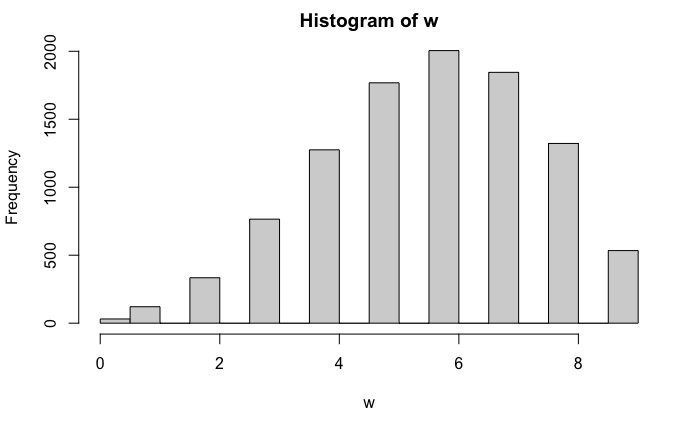

- **PRIOR Predicitve** works the same but with samples from the prior (before seeing the data)
- Very useful in complex models if we have to choose priors and don’t understand them in isolation
- Makes it understandable, what Priors “mean” → choose them knowingly, not by default

# 03 | Geocentric Models

- Intro to Linear Regression
- Basics of the Gaussian / Normal Distribution
- **data distribution** as a better term for “likelihood” (non-bayesian term)

## Workflow of Drawing the Owl

1. Question/goal Some Relationship between Heigth and Weight

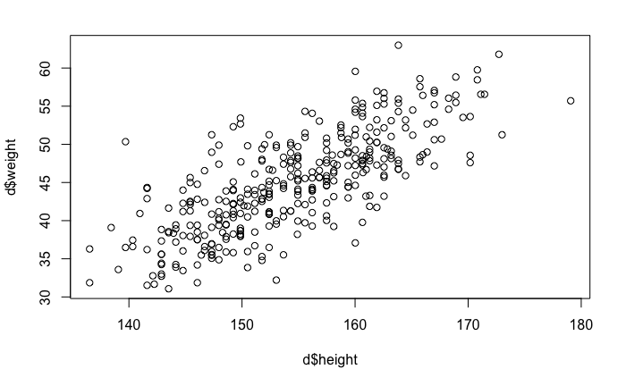

2. Scientific Model How does height influence weight Weight is some function of height: H → W (causal with ONE direction) W = f(H) → Weight is some function of Height

Generative Models (1) Dynamic Model: Simulation of growth from birth (more elegant solution, but not done in this example) → Incremental growth (2) Static Model: Changes of height result in changes of weight but no mechanism

- In linear Regression, the line does not tell where the OBSERVED values are, but where the mean expected values will be

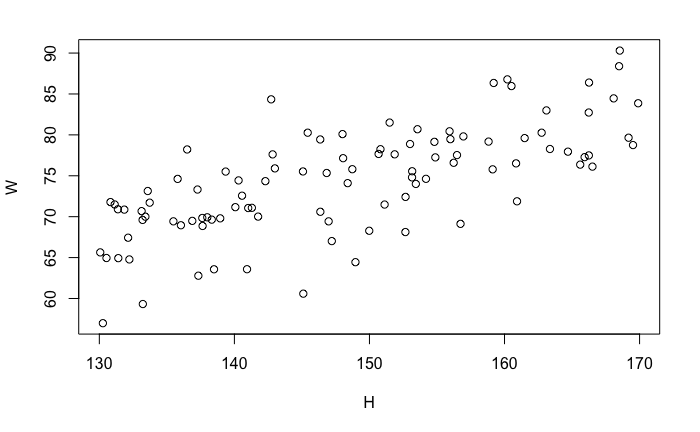

3. Statistical Model
- Differences to Scientific Model (2):
  - Priors
  - Parameter Values are unknown
- Sigma is a “scale parameter”
  - Their value streches some distibution
  - Value is always positive → prior z.B. uniform

Sampling the prior distribution:

```r
library(rethinking)
data(Howell1)
d <- Howell1[Howell1$age>=18, ]

n_samples <- 10
alpha <- rnorm(n_samples, 0, 1)
beta <- rnorm(n_samples, 0, 1)

#plot(NULL, xlim = c(-2, 2), ylim = c(-2, 2),
#     xlab = "x", ylab = "y")
#for (i in 1:n_samples) {
#  abline(alpha[i], beta[i], lwd = 4, col = 2)
#}
```

→ after that we could add more data points and see, that the lines get more and more confined

Structure of statistical model similar to generative model BUT:

- useful to rescale variables → changes meaning: e.g. if we rescale *height*, alpha is now the expected weight, if a person is of **average** height
- must think about priors
  - alpha (with the new meaning in mind): for example look up the average weight in africa and use it for the prior → a ~ normal(60, 10) → 10 is a very large SD
  - beta (always consider the unit: here kg per centimeter): b ~ normal(0, 10) means that we are neutral (relationship can be positive or negative, 10 is very wide SD)
  - sigma: uniform(0, 10) → SD of 10 is a variance of 100 (this would mean a huge spread on weight for any given heigth)

Sampled regression lines (before estimation)

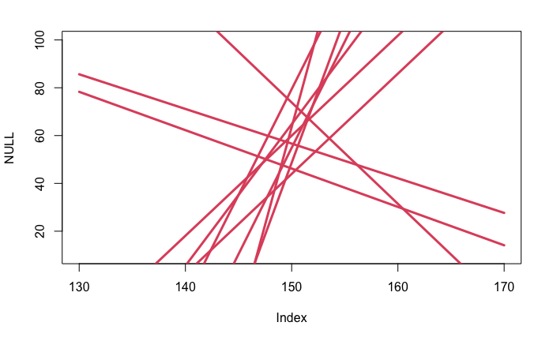

```r
n = 10
alpha = rnorm(n, 60, 10)
beta = rnorm(n, 0, 10)

Hbar <- 150
Hseq <- seq(from = 130, to = 170, len = 30)
plot(NULL, xlim = c(130, 170), ylim = c(10, 100))
for (i in 1:n) {
  lines(Hseq, alpha[i] + beta[i]*(Hseq-Hbar), lwd = 3, col = 2)
}
```

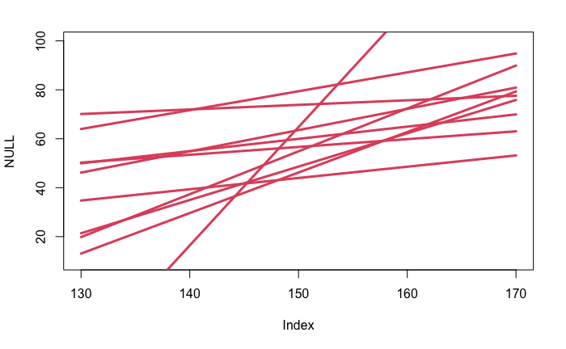

```r
# lines are all over the place --> because beta can be negative --> makes no sense
# therefore constrain beta to positive: LogNormal --> if you took the log of all
# the values in the distribution, the distribution would be normal
# --> LogNormal(0, 1) --> numbers refer to the distribution after the log
beta = rlnorm(n, 0, 1)

plot(NULL, xlim = c(130, 170), ylim = c(10, 100))
for (i in 1:n) {
  lines(Hseq, alpha[i] + beta[i]*(Hseq-Hbar), lwd = 3, col = 2)
}
```

Priors * There is no “right” prior * Statistical and/or scientific argument needed * Justified with information **outside** the data * Priors matter less in simple models like the example above **BUT** they matter more e.g. in multilevel models → in these models the priors are learned from the data itself * for the model above the Posterior is Pr(a,b,sigma | W, H)

Quadratic approximation → many posterior distributions are approximately Gaussian → Laplace is the most influential person in bayesian Statistics → should maybe called laplacian Statistics

(4 & 5) Validate Model & Analyze Data

- Take data from the previous simulation (scientific model, step 2) and put it into the statistical model
- **Simulation based Calibration** We know the mechanics of the scientific model → if it is consistent with the data, the statistical model should recover these values → later: deep dive simulation-based calibration

Validate with simulation

|  | mean | sd | 5.5% | 94.5% |
| --- | --- | --- | --- | --- |
| a | 69.82 | 0.44 | 69.12 | 70.52 |
| b | 0.48 | 0.04 | 0.42 | 0.54 |
| sigma | 4.40 | 0.31 | 3.90 | 4.90 |

Repeat with the real data

```r
data(Howell1)
d <- Howell1[Howell1$age>=18, ]

dat <- list(W = d$weight,
            H = d$height,
            Hbar = mean(d$height))

m_adults <- quap(
  alist(
    W ~ dnorm(mu, sigma),
    mu <- a + b * (H - Hbar),
    a ~ dnorm(60, 10),
    # keep in mind meaning for scaled values of H
    b ~ dlnorm(0, 1),
    sigma ~ dunif(0, 10)
), data = dat)

precis(m_adults)
```

|  | mean | sd | 5.5% | 94.5% |
| --- | --- | --- | --- | --- |
| a | 45.00 | 0.23 | 44.64 | 45.36 |
| b | 0.63 | 0.03 | 0.58 | 0.68 |
| sigma | 4.23 | 0.16 | 3.97 | 4.48 |

**First Law of Statistical Interpretation**: > The parameters are not independent of one another and cannot always be independently interpreted

→ Covariation between parameter values is very common → Instead: Push out posterior predictions and describe/interpret those (analogous to the globe tossing example)

## Posterior predictive distribution

1. Plot the sample
2. Plot the posterior mean
3. Plot uncertainty of the mean
4. Plot uncertainty of predictions

```r
#plot( height ~ weight , data=d , col=col.alpha(rangi2,0.5) )

# maybe interesting in the future: Lecture 03; 1:16:00 for more code to actually create visualization
```

# 04 | Categories, Curves & Splines

```r
data("Howell1")
d$male <- as.factor(d$male)
ggplot(d)+geom_point(aes(d$height, d$weight, color = d$male))
```

[output not shown]

Research Question: influence of height and sex on weight * how are height, weight and sex *causally* related? * how are height, weight and sex *statistically* related? → Causes aren’t in the data

→ weiter ab 8 Minuten